# BDBM Assignment 6

shaistamadad

4/30/2020

## Setting seed option after every sampling to get consistent results

```r
library(e1071)  #need this library for svm modelling
library(readr)
library(AUC) # to make AUC cruves
all_cancer_data <- read_csv("data.csv",col_names = TRUE)
cancer_data = all_cancer_data[,c("radius_mean", "texture_mean", "smoothness_mean", "compactness_mean", "diagnosis")]
cancer_data$diagnosis = as.factor(cancer_data$diagnosis)
```

```r
table(cancer_data[,"diagnosis"])  # more benign, this will bring a bias in the model
```

```
##
##   B   M
## 357 212
```

```r
set.seed(1)
allMalignant<-cancer_data[which(cancer_data[,"diagnosis"] == 'M'),] # choose all the data with maligant diagnosis
allBenign<-cancer_data[which(cancer_data[,"diagnosis"] == 'B'),]   # choose all the data with benign diagnosis
sample(1:nrow(allBenign), nrow(allMalignant))->rand.0  # sample from the benign vector number of variables = 212, which is the number of malignant data points
allBenign[rand.0,]->benign  # 212 benign data points
allMalignant -> malignant  #212 malignant points
```

```r
set.seed(2)
training.malignant<-sample(nrow(allMalignant), floor(nrow(allMalignant) * 0.8), replace = FALSE) #choose 80 percent of the 212 malignant malignant points
set.seed(3)
training.benign= sample(nrow(benign), floor(nrow(benign) * 0.8), replace = FALSE) #choose 80 percent of the 212 malignant malignant points
training_set_balanced_malignant<-allMalignant[training.malignant,] # 80 percent allMalignant for training set
test_set_balanced_malignant<-allMalignant[-training.malignant,] # 20 percent chosen as test dataset

training_set_balanced_benign<-allBenign[training.benign,] # 80 percent allBenign for training set
test_set_balanced_benign<-benign[-training.benign,] # 20 percent chosen as test dataset
```

# BALANCED TRAINING AND TEST DATASETS

```r
training_set_balanced= rbind(training_set_balanced_malignant, training_set_balanced_benign)
test_set_balanced= rbind(test_set_balanced_malignant, test_set_balanced_benign)
```

```r
table(training_set_balanced[,"diagnosis"])  # equal ratio of benign and malignant in test dataset
```

```
##
##   B   M
## 169 169
```

```r
table(test_set_balanced[,"diagnosis"]) # equal proportion of benign and malignant in training dataset
```

```
##
##  B  M
## 43 43
```

```r
str(test_set_balanced)
```

```
## Classes 'tbl_df', 'tbl' and 'data.frame':    86 obs. of  5 variables:
##  $ radius_mean     : num  11.4 18.2 12.5 19.3 13.3 ...
##  $ texture_mean    : num  20.4 20 24 26.5 20.3 ...
##  $ smoothness_mean : num  0.1425 0.0946 0.1186 0.094 0.1041 ...
##  $ compactness_mean: num  0.284 0.109 0.24 0.172 0.144 ...
##  $ diagnosis       : Factor w/ 2 levels "B","M": 2 2 2 2 2 2 2 2 2 2 ...
##  - attr(*, "problems")=Classes 'tbl_df', 'tbl' and 'data.frame': 569 obs. of  5 variables:
##   ..$ row     : int  1 2 3 4 5 6 7 8 9 10 ...
##   ..$ col     : chr  NA NA NA NA ...
##   ..$ expected: chr  "33 columns" "33 columns" "33 columns" "33 columns" ...
##   ..$ actual  : chr  "32 columns" "32 columns" "32 columns" "32 columns" ...
##   ..$ file    : chr  "'data.csv'" "'data.csv'" "'data.csv'" "'data.csv'" ...
```

```r
str(training_set_balanced)
```

```
## Classes 'tbl_df', 'tbl' and 'data.frame':    338 obs. of  5 variables:
##  $ radius_mean     : num  19.2 15.2 15.5 12.4 25.7 ...
##  $ texture_mean    : num  15.9 30.6 23.9 15.7 17.5 ...
##  $ smoothness_mean : num  0.0869 0.1048 0.1183 0.1278 0.1149 ...
##  $ compactness_mean: num  0.118 0.209 0.187 0.17 0.236 ...
##  $ diagnosis       : Factor w/ 2 levels "B","M": 2 2 2 2 2 2 2 2 2 2 ...
##  - attr(*, "problems")=Classes 'tbl_df', 'tbl' and 'data.frame': 569 obs. of  5 variables:
##   ..$ row     : int  1 2 3 4 5 6 7 8 9 10 ...
##   ..$ col     : chr  NA NA NA NA ...
##   ..$ expected: chr  "33 columns" "33 columns" "33 columns" "33 columns" ...
##   ..$ actual  : chr  "32 columns" "32 columns" "32 columns" "32 columns" ...
##   ..$ file    : chr  "'data.csv'" "'data.csv'" "'data.csv'" "'data.csv'" ...
```

## Function to calcuate the best model for different values of c

I used the tune.svm function to get the best model and calculate the auc for the best model

```r
set.seed(44)

SVM_AUC <- function(training_set_balanced, test_set_balanced){



svm <- tune.svm(diagnosis~radius_mean +texture_mean+smoothness_mean+compactness_mean, data = training_set_balanced, kernal = "linear",cost=seq(from=0.1, to=20,by=0.1), probability = T)
print(svm$best.model) # the best model from costs 0.1 to 20

svm.prob <- predict(svm$best.model, test_set_balanced[,1:4],probability=T)
#print(svm.prob)
prob <- attr(svm.prob,"probabilities")[,"M"]
return(auc(roc(prob, test_set_balanced$diagnosis)))
}


SVM_AUC(training_set_balanced= training_set_balanced , test_set_balanced = test_set_balanced)
```

```
##
## Call:
## best.svm(x = diagnosis ~ radius_mean + texture_mean + smoothness_mean +
##     compactness_mean, data = training_set_balanced, cost = seq(from = 0.1,
##     to = 20, by = 0.1), kernal = "linear", probability = T)
##
##
## Parameters:
##    SVM-Type:  C-classification
##  SVM-Kernel:  radial
##        cost:  0.8
##
## Number of Support Vectors:  92
```

```
## [1] 0.9745809
```

##Using the tune.svm, I get the best model at cost= 0.8 , and my auc for test data id 0.9745809. HOwever, the tune.svm also changes the kernel from linear to radial. I am not sure if this assignment wants us to keep the kernel alway set at linear. If that’s the case, please consider the function I wrote below testing different values of c while keeping the kernel= linear.

```r
set.seed(000)
SVM_Function= function(n){
  out<-matrix(data=NA, nrow = 4, ncol = n)
  rownames(out)<-c("sensitive:","specificity:","precision:","accuracy:")
  for (i in 1:n){
    data.svm = svm(diagnosis ~  radius_mean +texture_mean+smoothness_mean+compactness_mean,
            data = training_set_balanced, kernel="linear", cost=i,
            probability=T,scale = FALSE)
    data.svm.pred.prob = predict(data.svm, test_set_balanced,
                             probability=T)
tableA= table(data.svm.pred.prob,test_set_balanced$diagnosis)
data.svm.pred.prob.mat = attr(data.svm.pred.prob, "probabilities")
 TP=tableA["M","M"]
  TN=tableA["B","B"]
  FP=tableA["B","M"]
  FN=tableA["M","B"]
  TPR=(TP)/(TP+FN)
  TNR=(TN)/(TN+FP)
  PPV=(TP)/(TP+FP)
  ACC=(TP+TN)/(TP+TN+FP+FN)
  #c("sensitive:","specificity:","precision:","accuracy:")
  out[,i]=c(TPR,TNR,PPV,ACC)
  #rownames(out)<-c("sensitive:","specificity:","precision:","accuracy:")
  #c(TPR,TNR,PPV,ACC)
  }
  return(out)
}
```

```r
set.seed(1234)
SVM_Function(20)  # the sensitivity, specificity, accuracy and precision scores for models with costs changing from 1 to 20
```

```
##                   [,1]      [,2]      [,3]      [,4]      [,5]      [,6]
## sensitive:   0.8409091 0.8444444 0.8478261 0.8478261 0.8478261 0.8541667
## specificity: 0.8571429 0.8780488 0.9000000 0.9000000 0.9000000 0.9473684
## precision:   0.8604651 0.8837209 0.9069767 0.9069767 0.9069767 0.9534884
## accuracy:    0.8488372 0.8604651 0.8720930 0.8720930 0.8720930 0.8953488
##                   [,7]      [,8]      [,9]     [,10]     [,11]     [,12]
## sensitive:   0.8541667 0.8541667 0.8541667 0.8541667 0.8541667 0.8541667
## specificity: 0.9473684 0.9473684 0.9473684 0.9473684 0.9473684 0.9473684
## precision:   0.9534884 0.9534884 0.9534884 0.9534884 0.9534884 0.9534884
## accuracy:    0.8953488 0.8953488 0.8953488 0.8953488 0.8953488 0.8953488
##                  [,13]     [,14]     [,15]     [,16]     [,17]     [,18]
## sensitive:   0.8541667 0.8541667 0.8541667 0.8541667 0.8571429 0.8571429
## specificity: 0.9473684 0.9473684 0.9473684 0.9473684 0.9729730 0.9729730
## precision:   0.9534884 0.9534884 0.9534884 0.9534884 0.9767442 0.9767442
## accuracy:    0.8953488 0.8953488 0.8953488 0.8953488 0.9069767 0.9069767
##                  [,19]     [,20]
## sensitive:   0.8750000 0.8571429
## specificity: 0.9736842 0.9729730
## precision:   0.9767442 0.9767442
## accuracy:    0.9186047 0.9069767
```

However, fairly similar scores for most models, these scores are not reliable to calculate the best model.

## A function to get auc scores for testset predictions, using training set to train a model for different values of c

```r
SVM_AUC= function(n){
  out<-matrix(data=NA, nrow = 1, ncol = n)  # matrix to be filled with auc scores
  rownames(out)<-c("AUC")
  for (i in 1:n){
    data.svm = svm(diagnosis ~  radius_mean +texture_mean+smoothness_mean+compactness_mean,
            data = training_set_balanced, kernel="linear", cost=i,
            probability=T)
    data.svm.pred.prob = predict(data.svm, test_set_balanced,
                             probability=T)
    data.svm.pred.prob.mat = attr(data.svm.pred.prob, "probabilities")
    datasvmroc = roc(predictions = data.svm.pred.prob.mat[,1], test_set_balanced$diagnosis)
    out[,i]=auc(datasvmroc)
  }
  return(out)
}
```

##AUC scores for c= 1 to c=20 using the test set data

```r
set.seed(12345)
SVM_AUC(20)
```

```
##          [,1]      [,2]      [,3]      [,4]      [,5]      [,6]      [,7]
## AUC 0.9789075 0.9789075 0.9789075 0.9789075 0.9783667 0.9794484 0.9789075
##          [,8]      [,9]     [,10]     [,11]     [,12]     [,13]     [,14]
## AUC 0.9789075 0.9789075 0.9789075 0.9789075 0.9789075 0.9789075 0.9789075
##         [,15]     [,16]     [,17]     [,18]     [,19]     [,20]
## AUC 0.9789075 0.9789075 0.9789075 0.9789075 0.9789075 0.9789075
```

## In case we were meant to use the auc values using the training dataset to evaluate the performance of the model, please consider this.

```r
SVM_AUC_Training_Set= function(n){
  out<-matrix(data=NA, nrow = 1, ncol = n)  # matrix to be filled with auc scores
  rownames(out)<-c("AUC")
  for (i in 1:n){
    data.svm = svm(diagnosis ~  radius_mean +texture_mean+smoothness_mean+compactness_mean,
            data = training_set_balanced, kernel="linear", cost=i,
            probability=T)
    data.svm.pred.prob = predict(data.svm, training_set_balanced,
                             probability=T)
    data.svm.pred.prob.mat = attr(data.svm.pred.prob, "probabilities")
    datasvmroc = roc(predictions = data.svm.pred.prob.mat[,1], training_set_balanced$diagnosis)
    out[,i]=auc(datasvmroc)
  }
  return(out)
}
```

```r
set.seed(111)
SVM_AUC_Training_Set(20)
```

```
##          [,1]     [,2]     [,3]     [,4]      [,5]      [,6]      [,7]
## AUC 0.9897763 0.989006 0.989111 0.989111 0.9893561 0.9894612 0.9896012
##          [,8]      [,9]     [,10]     [,11]     [,12]     [,13]     [,14]
## AUC 0.9895662 0.9895662 0.9895662 0.9895662 0.9896012 0.9896012 0.9895312
##         [,15]     [,16]     [,17]     [,18]     [,19]     [,20]
## AUC 0.9895312 0.9895312 0.9895312 0.9895312 0.9895312 0.9895312
```

## AUC plot for the best model c=1 when kernel= linear

```r
set.seed(29)
data.svm = svm(diagnosis ~  radius_mean +texture_mean+smoothness_mean+compactness_mean,
            data = training_set_balanced, kernel="linear", cost=1,
            probability=T)
```

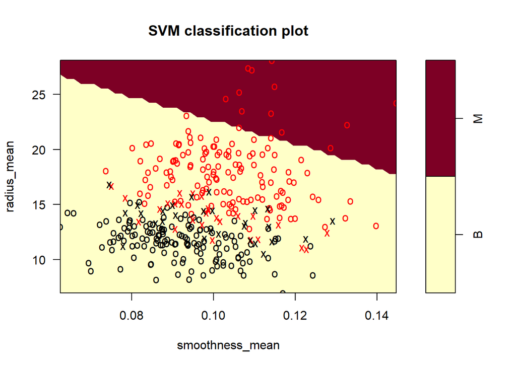

```r
plot(data.svm, training_set_balanced,  radius_mean~smoothness_mean)
```

#Testing the model

```r
data.svm.pred.prob = predict(data.svm, newdata=test_set_balanced,
                             probability=T)
table(data.svm.pred.prob,test_set_balanced$diagnosis)
```

```
##
## data.svm.pred.prob  B  M
##                  B 35  2
##                  M  8 41
```

```r
data.svm.pred.prob.mat = attr(data.svm.pred.prob, "probabilities")
```

The probabilities are stored as an attribute in the results. You can retrieve it using the attr function.

```r
head(data.svm.pred.prob.mat) # first column are theprobabilities for maligant
```

```
##           M            B
## 1 0.9926718 0.0073281928
## 2 0.9911925 0.0088075427
## 3 0.9872270 0.0127729795
## 4 0.9999121 0.0000879044
## 5 0.6952697 0.3047303080
## 6 0.9986932 0.0013067565
```

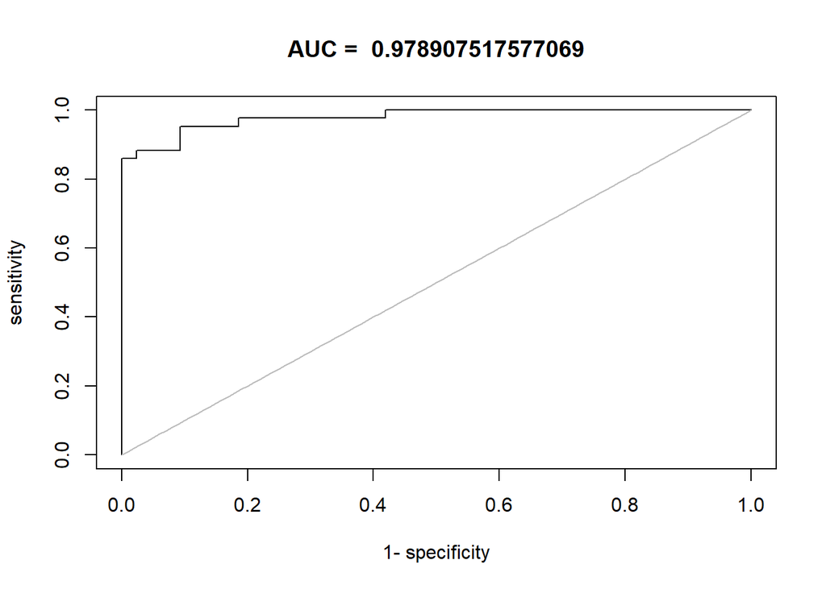

```r
datasvmroc = roc(predictions = data.svm.pred.prob.mat[,1], test_set_balanced$diagnosis)
auc_result=auc(datasvmroc)  # I need the prediction probabilities for maligant diagnosis
plot(datasvmroc,main=paste("AUC = ", auc(datasvmroc), sep=" "))
```

#Neural Network ## Scale Data

```r
all_cancer_data1 <- read_csv("data.csv",col_names = TRUE)
cancer_data1 = all_cancer_data1[,c("radius_mean", "texture_mean", "smoothness_mean", "compactness_mean", "diagnosis")]
cancer_data1$diagnosis = as.factor(cancer_data1$diagnosis)
```

```r
maxs = apply(cancer_data1[,1:4], 2, max)
mins = apply(cancer_data1[,1:4], 2, min)
```

```r
scaled.data = as.data.frame(scale(cancer_data1[,1:4],
                                  center=mins,
                                  scale = maxs-mins))

diagnosis = as.numeric(cancer_data1$diagnosis)-1

scaled.data.df = cbind(diagnosis,scaled.data)
```

```r
set.seed(7666) # setting seed after every sampling to get consistent results
allMalignant1<-scaled.data.df[which(scaled.data.df[,"diagnosis"] == "1"),] # choose all the data with maligant diagnosis
set.seed(7888)
allBenign1<-scaled.data.df[which(scaled.data.df[,"diagnosis"] == "0"),]   # choose all the data with benign diagnosis
set.seed(888)
sample(1:nrow(allBenign1), nrow(allMalignant1))->rand.01  # sample from the benign vector number of variables = 212, which is the number of malignant data points
allBenign1[rand.01,]->benign1  # 212 benign data points
allMalignant1 -> malignant1 #212 malignant points
```

```r
set.seed(25)
training.malignant1<-sample(nrow(allMalignant1), floor(nrow(allMalignant1) * 0.8), replace = FALSE) #choose 80 percent of the 212 malignant malignant points
set.seed(26)
training.benign1= sample(nrow(benign1), floor(nrow(benign1) * 0.8), replace = FALSE) #choose 80 percent of the 212 malignant malignant points
training_set_balanced_malignant1<-allMalignant1[training.malignant1,] # 80 percent allMalignant for training set
test_set_balanced_malignant1<-allMalignant1[-training.malignant1,] # 20 percent chosen as test dataset

training_set_balanced_benign1<-allBenign1[training.benign1,] # 80 percent allBenign for training set
test_set_balanced_benign1<-benign1[-training.benign1,] # 20 percent chosen as test dataset
```

# BALANCED TRAINING AND TEST DATASETS

```r
training_set_balanced1= rbind(training_set_balanced_malignant1, training_set_balanced_benign1)
test_set_balanced1= rbind(test_set_balanced_malignant1, test_set_balanced_benign1)
```

```r
table(training_set_balanced1[,"diagnosis"])  # equal ratio of benign and malignant in test dataset
```

```
##
##   0   1
## 169 169
```

```r
table(test_set_balanced1[,"diagnosis"])
```

```
##
##  0  1
## 43 43
```

```r
set.seed(2222)
library("neuralnet")
get_NN_AUC <- function(n){

#training_set_balanced1$diagnosis= as.factor(training_set_balanced1$diagnosis)
#test_set_balanced1$diagnosis= as.factor(test_set_balanced1$diagnosis)


data.nn = neuralnet(diagnosis~ radius_mean +texture_mean+smoothness_mean+compactness_mean, data=training_set_balanced1, hidden=c(n), rep=1, linear.output = F)
data.nn.results =compute(data.nn, test_set_balanced1[,2:5])
#print()
#training_set_balanced$diagnosis <- ifelse(training_set_balanced$diagnosis =="M",1,0)
#test_set_balanced$diagnosis= ifelse(test_set_balanced$diagnosis =="M",1,0)
data.nn.roc = roc(data.nn.results$net.result,as.factor(test_set_balanced1$diagnosis))

return(auc(data.nn.roc))
}

get_NN_AUC(1)
```

```
## [1] 0.9853975
```

```r
get_NN_AUC(10)
```

```
## [1] 0.9734992
```

```r
get_NN_AUC(20)
```

```
## [1] 0.951325
```

```r
set.seed(777)
out= matrix( nrow=1, ncol=30)
for (i in c(1:30)){
  rownames(out)= c("AUC")
  colnames(out)= c(1:30)
  #auc= get_NN_AUC(i)
out[,i]= get_NN_AUC(i)
}
```

```r
out
```

```
##             1         2         3         4         5         6         7
## AUC 0.9853975 0.9767442 0.9724175 0.9567334 0.9691725 0.9716063 0.9689021
##             8         9        10        11        12        13        14
## AUC 0.9732288 0.9762034 0.9697134 0.9505138 0.9778259 0.9821525 0.9613304
##          15        16      17        18        19        20        21        22
## AUC 0.97404 0.9605192 0.98053 0.9651163 0.9778259 0.9664684 0.9759329 0.9699838
##            23        24        25       26        27        28        29
## AUC 0.9613304 0.9816117 0.9599784 0.977285 0.9670092 0.9751217 0.9572742
##            30
## AUC 0.9826933
```

## So the highest auc score is when the size of layers is 1(0.9853975)

## AUC plot when layers= 1

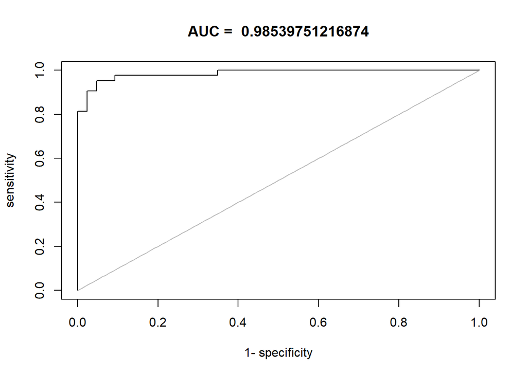

```r
set.seed(77)
data.nn = neuralnet(diagnosis~., data=training_set_balanced1, hidden=1, rep=1, linear.output = F)
data.nn.results =neuralnet::compute(data.nn, test_set_balanced1[,2:5])

data.nn.roc = roc(data.nn.results$net.result,
                  as.factor(test_set_balanced1$diagnosis))
plot(data.nn.roc,main=paste("AUC = ", auc(data.nn.roc), sep=" "))
```

```r
plot(data.nn)
```

[output not shown]

##AUC plot when layer= 10

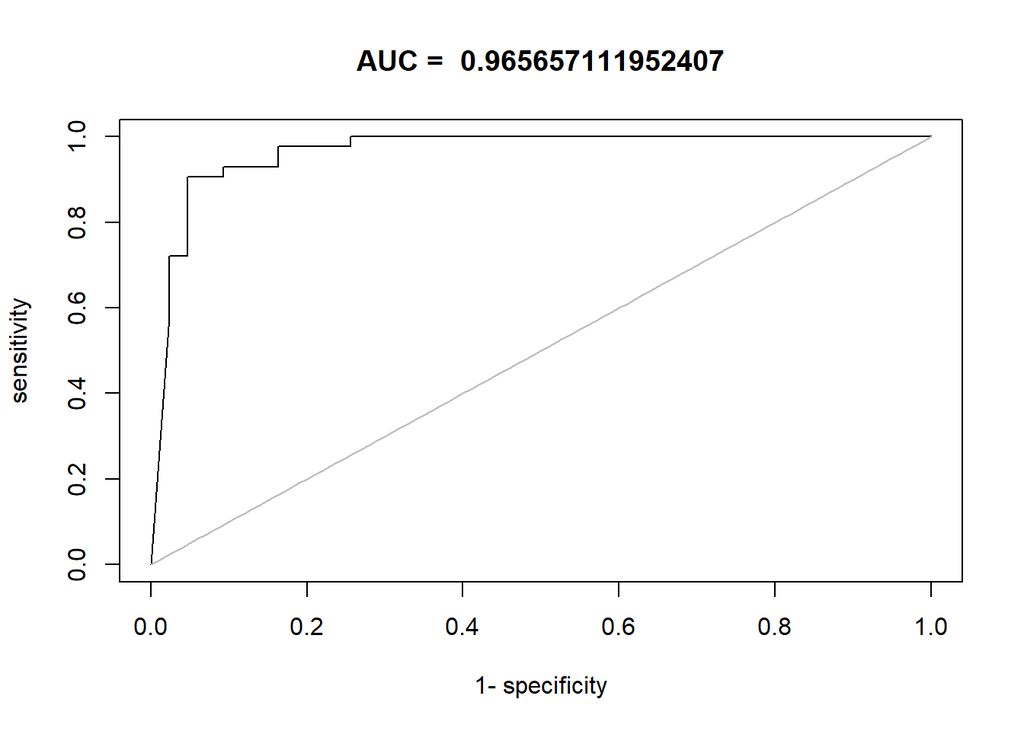

```r
set.seed(00)
data.nn = neuralnet(diagnosis~., data=training_set_balanced1, hidden=10, rep=1, linear.output = F)
data.nn.results =neuralnet::compute(data.nn, test_set_balanced1[,2:5])

data.nn.roc = roc(data.nn.results$net.result,
                  as.factor(test_set_balanced1$diagnosis))
plot(data.nn.roc,main=paste("AUC = ", auc(data.nn.roc), sep=" "))
```

##AUC plot when layer= 20

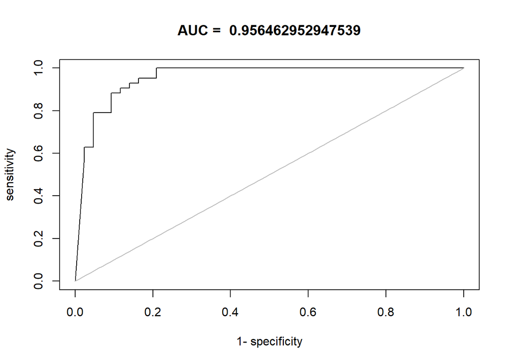

```r
set.seed(8)
data.nn = neuralnet(diagnosis~., data=training_set_balanced1, hidden=20, rep=1, linear.output = F)
data.nn.results =neuralnet::compute(data.nn, test_set_balanced1[,2:5])

data.nn.roc = roc(data.nn.results$net.result,
                  as.factor(test_set_balanced1$diagnosis))
plot(data.nn.roc,main=paste("AUC = ", auc(data.nn.roc), sep=" "))
```

## In conclusion , the best model is at size = 1 AUC= 0.98539751216874